# Лабораторна робота № 1

## Вхідний аналіз набору даних

**Дисципліна:** Інтелектуальний аналіз та візуалізація даних (СК26) **Тривалість:** 2 год аудиторно + 3 год самостійної роботи · **Максимальна оцінка:** 4 бали

### Мета роботи

Пригадати роботу в Jupyter Notebook, бібліотеці `pandas` та побудову графіків — і зробити це не на навчальному прикладі, а на реальному файлі, який ніхто не готував спеціально для вас.

Ця робота виконується **до першої лекції**. Нічого нового знати не потрібно: усе, що знадобиться, ви вже проходили в попередніх курсах. Усі поняття, яких ви тут торкнетеся мимохідь, отримають назви й пояснення на лекціях 3 і 4.

### Дані

Файл `20171129_FINAL_FINAL.xlsx`, аркуш `Sheet1` — спостереження космічної погоди за 28 серпня — 22 вересня 2017 року, зібрані з трьох різних джерел.

Файл видається **як є**, рівно в тому вигляді, у якому його колись вивантажили. Ніхто не приводив його до ладу, і саме в цьому сенс: справжні дані здебільшого надходять саме такими.

### Що ви маєте зробити

| Етап | Зміст | Де |
| --- | --- | --- |
| 1 | Розібратися, що взагалі лежить у файлі | аудиторно |
| 2 | Виділити три таблиці й привести їх до робочого вигляду | аудиторно |
| 3 | Скласти паспорт даних: що є, чого бракує, що виглядає дивно | аудиторно |
| 4 | Об'єднати три таблиці в одну | аудиторно |
| 5 | Побудувати п'ять графіків, кожен — відповідь на питання | аудиторно + самостійно |
| 6 | Порівняти два графіки одних і тих самих даних | самостійно |
| 7 | Записати три спостереження про дані | самостійно |
| 8 | Декларація про використання інструментів ШІ | самостійно |

### Що здається

1. Цей файл `.ipynb` із заповненими розв'язками. **Ноутбук має виконуватися згори донизу на чистому ядрі** (Kernel → Restart & Run All) без помилок — це перевіряється першою дією на захисті.
2. Файл `master_hourly.csv` — об'єднана таблиця з етапу 4.
3. Експорт ноутбука у HTML або PDF.
4. Заповнена декларація (етап 8). Без неї фінальна самоперевірка не проходить.

### Критерії оцінювання

| Бали | Що досягнуто |
| --- | --- |
| 0 | Дані не опрацьовано, графіки не побудовано або побудовано з грубими помилками |
| 1 | Таблиці прочитано й кілька графіків побудовано, але типи графіків не відповідають даним, дивних значень не помічено |
| 2 | Таблиці розібрано й об'єднано, графіки коректні та підписані, але висновків під ними немає або вони формальні |
| 4 | Усе вище виконано, знайдено й пояснено дивні значення, під кожним графіком є змістовний висновок про дані |

**Головне про оцінку:** бали ставляться не за наявність графіка, а за речення під ним. Код, який нічого не пояснює, коштує двох балів з чотирьох.

## Нагадування про Jupyter

Якщо давно не працювали — три речі, які знадобляться сьогодні:

- `Shift+Enter` виконує клітинку, `Esc` `A` / `Esc` `B` додає клітинку вище / нижче, `Esc` `M` перетворює клітинку на текстову (Markdown), `Esc` `Y` — назад на код.
- **Порядок виконання має значення.** Якщо ви правили клітинки в довільному порядку, результат може залежати від історії запусків. Перед здачею обов'язково **Kernel → Restart & Run All** — так ви побачите ноутбук очима викладача.
- Текстові клітинки — не прикраса. Висновки пишуться в них, а не в коментарях до коду.

## Крок 0. Ваші дані та варіант

Заповніть три змінні й виконайте обидві клітинки. Друга надрукує **ваше індивідуальне завдання** — воно відрізняється від завдання сусіда.

```python
ПІБ = 'Бугай Софія'        # напр. 'Шевченко Тарас'
ГРУПА = 'ШІ-34'      # напр. 'КН-31'
ВАРІАНТ = 2     # ваш номер за списком групи

assert ПІБ and ГРУПА and ВАРІАНТ, 'Заповніть ПІБ, ГРУПУ та ВАРІАНТ'
```

```python
# --- клітинку не редагувати: вона видає ваше персональне завдання ------------
ПОТОКИ = ['P>1', 'P>5', 'P>10', 'P>30', 'P>50', 'P>100', 'E>0.8', 'E>2.0']

ПАРИ = [('швидкість вітру', 'густина вітру'),
        ('швидкість вітру', 'потік P>10'),
        ('густина вітру', 'потік P>1'),
        ('радіопотік F10.7', 'потік P>10'),
        ('радіопотік F10.7', 'швидкість вітру'),
        ('потік E>0.8', 'потік P>10')]

АГРЕГАТИ = ['середнє', 'максимум', 'медіана', 'мінімум']

ПИТАННЯ = [
    'Скільки годин за все вікно ваш потік перевищував своє власне медіанне значення?',
    'У яку добу середнє значення вашого потоку було найбільшим? А найменшим?',
    'О котрій годині доби потік E>0.8 у середньому найбільший? Побудуйте графік середнього за годинами доби.',
    'Яка частка рядків об’єднаної таблиці має пропуск хоча б в одному стовпці?',
    'У який день радіопотік F10.7 був найбільшим і чи збігається цей день з піком вашого потоку?',
    'Порівняйте медіану вашого потоку за перший і за другий тиждень спостережень. У скільки разів вони відрізняються?',
    'Скільки годин поспіль тривала найдовша неперервна серія «активних» годин (група з етапу 4)?',
    'Який зі стовпців об’єднаної таблиці має найбільший розкид відносно власного середнього?',
    'Яку частку сумарного значення вашого потоку за все вікно дали 24 години навколо піку?',
    'Скільки різних діб потрапило у групу «активні» і скільки — у групу «дуже активні»?',
]

i = int(ВАРІАНТ)
завдання = {
    'ваш потік':                      ПОТОКИ[(i * 3 + 1) % 8],
    'ваша пара для графіка 3':        ' та '.join(ПАРИ[(i * 5 + 2) % 6]),
    'ваш агрегат для етапу 4':        АГРЕГАТИ[(i * 5 + 1) % 4],
    'ваше додаткове питання':         ПИТАННЯ[(i * 11 + 5) % 10],
}

print('ІНДИВІДУАЛЬНЕ ЗАВДАННЯ · %s, %s, варіант %d' % (ПІБ, ГРУПА, i))
print('=' * 78)
for k, v in завдання.items():
    print('%-28s %s' % (k + ':', v))
```

```
ІНДИВІДУАЛЬНЕ ЗАВДАННЯ · Бугай Софія, ШІ-34, варіант 2
==============================================================================
ваш потік:                   E>2.0
ваша пара для графіка 3:     швидкість вітру та густина вітру
ваш агрегат для етапу 4:     мінімум
ваше додаткове питання:      Який зі стовпців об’єднаної таблиці має найбільший розкид відносно власного середнього?
```

Далі за текстом **«ваш потік»** означає стовпець, названий у першому рядку завдання.

```python
import pandas as pd
import numpy as np
import matplotlib.pyplot as plt
import seaborn as sns

pd.set_option('display.width', 200)
pd.set_option('display.max_columns', 40)
plt.rcParams.update({'figure.dpi': 110, 'axes.spines.top': False,
                     'axes.spines.right': False, 'font.size': 9})

ФАЙЛ = '20171129_FINAL_FINAL.xlsx'
```

# Етап 1. Що взагалі лежить у файлі

Перше правило роботи з незнайомими даними: спершу подивитися, потім рахувати.

### Завдання 1.1

Спробуйте прочитати аркуш `Sheet1` звичайним способом — `pd.read_excel(ФАЙЛ)` — і виведіть перші рядки та типи стовпців.

*Очікуваний результат: результат буде дивним. Подивіться на назви стовпців і на те, які там типи даних. Поясніть у наступній клітинці, чому так вийшло.*

```python
# ВАШ КОД
dp = pd.read_excel(ФАЙЛ)
print(dp.head(25))
```

```
    Unnamed: 0        ftp://ftp.swpc.noaa.gov/pub/lists/particle/ Unnamed: 2 Unnamed: 3 Unnamed: 4 Unnamed: 5 Unnamed: 6 Unnamed: 7 Unnamed: 8 Unnamed: 9 Unnamed: 10 Unnamed: 11 Unnamed: 12  \
0          NaN                                                NaN        NaN        NaN        NaN        NaN        NaN        NaN        NaN        NaN         NaN         NaN         NaN
1          NaN                :Data_list: 20170901_Gs_part_5m.txt        NaN        NaN        NaN        NaN        NaN        NaN        NaN        NaN         NaN         NaN         NaN
2          NaN                     :Created: 2017 Sep 02 0011 UTC        NaN        NaN        NaN        NaN        NaN        NaN        NaN        NaN         NaN         NaN         NaN
3          NaN  # Prepared by the U.S. Dept. of Commerce, NOAA...        NaN        NaN        NaN        NaN        NaN        NaN        NaN        NaN         NaN         NaN         NaN
4          NaN  # Please send comments and suggestions to SWPC...        NaN        NaN        NaN        NaN        NaN        NaN        NaN        NaN         NaN         NaN         NaN
5          NaN                                                 #         NaN        NaN        NaN        NaN        NaN        NaN        NaN        NaN         NaN         NaN         NaN
6          NaN               # Label: P > 1 = Particles at >1 Mev        NaN        NaN        NaN        NaN        NaN        NaN        NaN        NaN         NaN         NaN         NaN
7          NaN               # Label: P > 5 = Particles at >5 Mev        NaN        NaN        NaN        NaN        NaN        NaN        NaN        NaN         NaN         NaN         NaN
8          NaN              # Label: P >10 = Particles at >10 Mev        NaN        NaN        NaN        NaN        NaN        NaN        NaN        NaN         NaN         NaN         NaN
9          NaN              # Label: P >30 = Particles at >30 Mev        NaN        NaN        NaN        NaN        NaN        NaN        NaN        NaN         NaN         NaN         NaN
10         NaN              # Label: P >50 = Particles at >50 Mev        NaN        NaN        NaN        NaN        NaN        NaN        NaN        NaN         NaN         NaN         NaN
11         NaN             # Label: P>100 = Particles at >100 Mev        NaN        NaN        NaN        NaN        NaN        NaN        NaN        NaN         NaN         NaN         NaN
12         NaN             # Label: E>0.8 = Electrons at >0.8 Mev        NaN        NaN        NaN        NaN        NaN        NaN        NaN        NaN         NaN         NaN         NaN
13         NaN             # Label: E>2.0 = Electrons at >2.0 Mev        NaN        NaN        NaN        NaN        NaN        NaN        NaN        NaN         NaN         NaN         NaN
```

[output cut: 65 more lines]

**Відповідь 1.1:** Функція, без додаткових аргументів, зчитує кожну клітинку, взявши за назви стовпців значення клітинки відповідного стовпця у першому ряді. Усі пусті клітинки функція зчитує як Nan, а пусті заголовки - як Unnamed : index. Без специфікації, назви рядків функція позначає як послідовний індекс (починаючи з 0). Максимальна кількість стовпців визначаєьбся тим, у якому останньому стовпці з'являються хоч якісь дані.

### Завдання 1.2

Прочитайте аркуш ще раз, але **без заголовка**: `pd.read_excel(ФАЙЛ, header=None)`. Виведіть його розмір і подивіться на перші 30 рядків.

```python
# ВАШ КОД
RAW = pd.read_excel(ФАЙЛ, header=None)
print("Розмір аркуша: ", RAW.size)
print("Довжина аркуша: ", RAW.shape[0])
print("Ширина аркуша: ", RAW.shape[1])
print("------------------------------------")
print(RAW.head(30))
```

```
Розмір аркуша:  231232
Довжина аркуша:  7226
Ширина аркуша:  32
------------------------------------
    0                                                  1    2    3     4         5        6      7      8      9       10      11      12     13     14  15  \
0  NaN        ftp://ftp.swpc.noaa.gov/pub/lists/particle/  NaN  NaN   NaN       NaN      NaN    NaN    NaN    NaN     NaN     NaN     NaN    NaN    NaN NaN
1  NaN                                                NaN  NaN  NaN   NaN       NaN      NaN    NaN    NaN    NaN     NaN     NaN     NaN    NaN    NaN NaN
2  NaN                :Data_list: 20170901_Gs_part_5m.txt  NaN  NaN   NaN       NaN      NaN    NaN    NaN    NaN     NaN     NaN     NaN    NaN    NaN NaN
3  NaN                     :Created: 2017 Sep 02 0011 UTC  NaN  NaN   NaN       NaN      NaN    NaN    NaN    NaN     NaN     NaN     NaN    NaN    NaN NaN
4  NaN  # Prepared by the U.S. Dept. of Commerce, NOAA...  NaN  NaN   NaN       NaN      NaN    NaN    NaN    NaN     NaN     NaN     NaN    NaN    NaN NaN
5  NaN  # Please send comments and suggestions to SWPC...  NaN  NaN   NaN       NaN      NaN    NaN    NaN    NaN     NaN     NaN     NaN    NaN    NaN NaN
6  NaN                                                 #   NaN  NaN   NaN       NaN      NaN    NaN    NaN    NaN     NaN     NaN     NaN    NaN    NaN NaN
7  NaN               # Label: P > 1 = Particles at >1 Mev  NaN  NaN   NaN       NaN      NaN    NaN    NaN    NaN     NaN     NaN     NaN    NaN    NaN NaN
8  NaN               # Label: P > 5 = Particles at >5 Mev  NaN  NaN   NaN       NaN      NaN    NaN    NaN    NaN     NaN     NaN     NaN    NaN    NaN NaN
9  NaN              # Label: P >10 = Particles at >10 Mev  NaN  NaN   NaN       NaN      NaN    NaN    NaN    NaN     NaN     NaN     NaN    NaN    NaN NaN
```

[output cut: 52 more lines]

### Завдання 1.3

Для кожного стовпця порахуйте, скільки в ньому заповнених клітинок (`RAW.notna().sum()`), і виведіть результат.

*Очікуваний результат: 32 числа. Серед них будуть нулі та згустки великих значень. За цими згустками видно, що в аркуші **не одна таблиця, а кілька**, вставлені поруч.*

**Питання:** скільки таблиць в аркуші і які стовпці займає кожна?

```python
# ВАШ КОД
print(RAW.notna().sum())
```

```
0        0
1     7223
2     7202
3     7202
4     7202
5     7203
6     7203
7     7198
8     7198
9     7198
10    7198
11    7198
12    7198
13    7198
14    7198
```

[output cut: 18 more lines]

**Відповідь 1.3:**

У стовпцях з 1го по 14тий схожа кількість заповнених клітинок (У перших стовпцях на декілька рядків більше). Це наша перша таблиця.

З 16го по 19тий стовпець також схожа кількість рядків -> це друга таблиця.

З 24го по 31ий стовпець наша остання таблиця -> третя

*Тобто у нас назагал є 3 таблиці.*

### Завдання 1.4

Над кожною таблицею є кілька текстових рядків — це службовий опис від тих, хто дані збирав. Виведіть їх і випишіть для кожної таблиці **джерело даних та одиниці вимірювання**.

*Це найкорисніші п'ять хвилин роботи: жодної з цих відомостей у самій таблиці немає, і без них ви не знатимете, у чому вимірюєте.*

```python
# ВАШ КОД
table_A = RAW.iloc[1:20, 1].to_string(index=False)
table_B = RAW.iloc[14:19, 16].to_string(index=False)
table_C = RAW.iloc[1:7, 26].to_string(index=False)

table = {'A': {'Origin' : RAW.iat[0,1], 'Units' : table_A},
         'B': {'Origin' : RAW.iat[13,16], 'Units' : table_B},
         'C': {'Origin' : RAW.iat[0,26], 'Units' : table_C}
}

pd.set_option('display.max_colwidth', None)
answer = pd.DataFrame(table).T

print(answer)
```

```
                                                           Origin  \
A                     ftp://ftp.swpc.noaa.gov/pub/lists/particle/
B  ftp://ftp.swpc.noaa.gov/pub/indices/old_indices/2017Q3_DSD.txt
C                                    http://umtof.umd.edu/pm/crn/

                                                                                                                                                                                                                                                                                                            …
A                                                 NaN\n               :Data_list: 20170901_Gs_part_5m.txt\n                    :Created: 2017 Sep 02 0011 UTC\n# Prepared by the U.S. Dept. of Commerce, NOAA,...\n# Please send comments and suggestions to SWPC....\n                                     …
B                                                                                                                                                                                                                                                                                                           …
C                                                                                                                                                                                                                                                                                                           …
```

**Відповідь 1.4:**

[output not shown]

# Етап 2. Три таблиці в робочому вигляді

У файлі три таблиці. Ось що в них лежить — решту ви вже знайшли самі:

| Таблиця | Стовпці аркуша | Що це | Один рядок = |
| --- | --- | --- | --- |
| A | B–O | вимірювання із супутника GOES-15: потоки частинок різної енергії | 5 хвилин |
| B | Q–T | добовий показник сонячної активності F10.7 | доба |
| C | Y–AF | швидкість і густина сонячного вітру | година |

### Завдання 2.1

Виділіть кожну таблицю в окремий `DataFrame` — назвіть їх `A`, `B` і `C`. Дайте стовпцям осмислені назви й перетворіть значення на числа (`pd.to_numeric(..., errors='coerce')` стане в пригоді).

```python
# ВАШ КОД

# A
A_table = RAW.iloc[26:7226, 1:15].to_numpy()
A_columns = ['Year', 'Month', 'Day', 'Hour:Minute', 'Julian date', 'Seconds in day', 'P>1', 'P>5', 'P>10', 'P>30', 'P>50', 'P>100', 'E>0.8', 'E>2.0']
float_columns = ['P>1', 'P>5', 'P>10', 'P>30', 'P>50', 'P>100', 'E>0.8', 'E>2.0']
A = pd.DataFrame(A_table, columns=A_columns)

for col in A.columns:
        if col not in float_columns:
            A[col] = pd.to_numeric(A[col], errors='coerce', downcast="integer")
        else:
            A[col] = pd.to_numeric(A[col], errors='coerce', downcast="float")

A.rename(columns={'Hour:Minute': 'Hour'}, inplace=True)
A_minutes = A['Hour'] % 100
A.insert(4, 'Minute', A_minutes)
A['Hour'] = A['Hour'] // 100

print("Таблиця A : \n", A.head(25))
print("-"*150)

# B
B_table = RAW.iloc[27:52, 16:20].to_numpy()
B_columns = ['Year', 'Month', 'Day', 'Radio Flux 10.7']
B = pd.DataFrame(B_table, columns=B_columns)

for col in B.columns:
    B[col] = pd.to_numeric(B[col], errors='coerce', downcast="integer")

print("Таблиця B : \n", B.head(25))
print("-"*150)

# C
C_table = RAW.iloc[27:628, 26:32].to_numpy()
C_columns = ['Year', 'Month', 'Day', 'Hour', 'Speed', 'Density']
C = pd.DataFrame(C_table, columns=C_columns)

for col in C.columns:
    if col != 'Density':
        C[col] = pd.to_numeric(C[col], errors='coerce', downcast="integer")
    else :
        C[col] = pd.to_numeric(C[col], errors='coerce', downcast="float")

C['Year'] = C['Year'].astype("int64") + 2000

print("Таблиця C : \n", C.head(25))
print("-"*150)
```

```
Таблиця A :
     Year  Month  Day  Hour  Minute  Julian date  Seconds in day    P>1    P>5   P>10    P>30    P>50   P>100    E>0.8   E>2.0
0   2017      8   28     0       0        57993               0  12.00  0.260  0.180  0.1140  0.1040  0.0793  23600.0  1180.0
1   2017      8   28     0       5        57993             300  19.40  0.690  0.314  0.1120  0.0612  0.0251  23100.0  1160.0
2   2017      8   28     0      10        57993             600   8.48  0.168  0.130  0.0717  0.0614  0.0304  22200.0  1090.0
3   2017      8   28     0      15        57993             900  15.40  0.566  0.198  0.0926  0.0568  0.0251  20400.0   997.0
4   2017      8   28     0      20        57993            1200   6.41  0.156  0.118  0.0597  0.0494  0.0251  18500.0   875.0
5   2017      8   28     0      25        57993            1500   9.94  0.495  0.310  0.2240  0.1780  0.0630  19600.0   950.0
6   2017      8   28     0      30        57993            1800   6.47  0.344  0.306  0.0650  0.0547  0.0268  19800.0   952.0
7   2017      8   28     0      35        57993            2100  11.00  0.334  0.121  0.0597  0.0494  0.0251  20100.0   966.0
8   2017      8   28     0      40        57993            2400   6.36  0.210  0.171  0.1130  0.1030  0.0572  20600.0   993.0
9   2017      8   28     0      45        57993            2700   6.41  0.188  0.150  0.0916  0.0814  0.0570  21600.0  1030.0
10  2017      8   28     0      50        57993            3000   6.34  0.180  0.142  0.0837  0.0734  0.0491  21400.0  1010.0
11  2017      8   28     0      55        57993            3300   9.13  0.308  0.175  0.0992  0.0583  0.0251  20400.0   936.0
12  2017      8   28     1       0        57993            3600  13.60  0.379  0.121  0.0597  0.0494  0.0251  20200.0   907.0
```

[output cut: 69 more lines]

### Завдання 2.2

У кожній таблиці дата й час записані **по-різному** й розкидані по кількох стовпцях. Зберіть для кожної таблиці один стовпець `ts` типу `datetime`.

Після цього обов'язково виведіть для кожної таблиці найранішу й найпізнішу дату.

*Очікуваний результат: усі три таблиці мають лежати в межах серпня–вересня 2017 року. Якщо у вас вийшов інший рік — придивіться, як записано рік у тій таблиці, і виправте.*

```python
# ВАШ КОД

tableA_time = pd.to_datetime(A[['Year', 'Month', 'Day', 'Hour', 'Minute']], errors='coerce', format='%Y-%m-%d %H:%M:00')
A.insert(A.shape[1], 'ts', tableA_time.sort_values(ascending=True))

table_B_time = pd.to_datetime(B[['Year', 'Month', 'Day']], errors='coerce', format='%Y-%m-%d')
B.insert(B.shape[1], 'ts', table_B_time.sort_values(ascending=True))

table_C_time = pd.to_datetime(C[['Year', 'Month', 'Day', 'Hour']], errors='coerce', format='%Y-%m-%d %H:00:00')
C.insert(C.shape[1], 'ts', table_C_time.sort_values(ascending=True))
```

**Самоперевірка етапу 2.** Клітинка має виконатися без помилок.

```python
assert len(A) == 7200, 'у таблиці A має бути 7200 рядків, а є %d' % len(A)
assert len(B) == 25,   'у таблиці B має бути 25 рядків, а є %d' % len(B)
assert len(C) == 601,  'у таблиці C має бути 601 рядок, а є %d' % len(C)
for назва, т in [('A', A), ('B', B), ('C', C)]:
    рік = pd.to_datetime(т['ts']).dt.year
    assert рік.min() == 2017 and рік.max() == 2017, 'у таблиці %s рік не 2017 — перевірте збирання дати' % назва
print('Етап 2 пройдено')
```

```
Етап 2 пройдено
```

# Етап 3. Паспорт даних

### Завдання 3.1

Для кожної таблиці виведіть: розмір, типи стовпців, кількість пропусків у кожному стовпці, кількість повних дублікатів рядків і описові статистики (`describe()`).

```python
# ВАШ КОД
print("Таблиця A : \n")
print("Розмір: ", A.shape[0], "x", A.shape[1])
print("Стовпці: ", A.columns.tolist())
print("Типи даних: \n---\n", A.dtypes, "\n---")
print("Кількість пропусків", A.isnull().sum().tolist())
print("Кількість дуплікатів", A.duplicated().sum())
print("Описові статистики: \n", A.describe(include="all"))
print("-"*170)
print("Таблиця B : \n")
print("Розмір: ", B.shape[0], "x", B.shape[1])
print("Стовпці: ", B.columns.tolist())
print("Типи даних: \n---\n", B.dtypes, "\n---")
print("Кількість пропусків", B.isnull().sum().tolist())
print("Кількість дуплікатів", B.duplicated().sum())
print("Описові статистики: \n", B.describe(include="all"))
print("-"*170)
print("Таблиця C : \n")
print("Розмір: ", C.shape[0], "x", C.shape[1])
print("Стовпці: ", C.columns.tolist())
print("Типи даних: \n---\n", C.dtypes, "\n---")
print("Кількість пропусків", C.isnull().sum().tolist())
print("Кількість дуплікатів", C.duplicated().sum())
print("Описові статистики: \n", C.describe(include="all"))
```

```
Таблиця A :

Розмір:  7200 x 16
Стовпці:  ['Year', 'Month', 'Day', 'Hour', 'Minute', 'Julian date', 'Seconds in day', 'P>1', 'P>5', 'P>10', 'P>30', 'P>50', 'P>100', 'E>0.8', 'E>2.0', 'ts']
Типи даних:
---
 Year                       int16
Month                       int8
Day                         int8
Hour                       int16
Minute                     int16
Julian date                int32
Seconds in day             int32
P>1                      float32
P>5                      float32
P>10                     float32
P>30                     float32
P>50                     float32
P>100                    float32
E>0.8                    float32
E>2.0                    float32
ts                datetime64[us]
dtype: object
---
Кількість пропусків [0, 0, 0, 0, 0, 0, 0, 3, 3, 3, 3, 3, 3, 3, 3, 0]
Кількість дуплікатів 0
Описові статистики:
          Year        Month          Day         Hour       Minute   Julian date  Seconds in day           P>1          P>5         P>10         P>30         P>50       P>100          E>0.8  \
count  7200.0  7200.000000  7200.000000  7200.000000  7200.000000   7200.000000     7200.000000   7197.000000  7197.000000  7197.000000  7197.000000  7197.000000  7197.00000    7197.000000
mean   2017.0     8.840000    13.960000    11.500000    27.500000  58005.000000    43050.000000    689.325073   156.626053    76.474014    18.838604     7.446839     1.65929   81862.742188
min    2017.0     8.000000     1.000000     0.000000     0.000000  57993.000000        0.000000      0.429000     0.151000     0.117000     0.057600     0.045500     0.02240       4.300000
25%    2017.0     9.000000     7.000000     5.750000    13.750000  57999.000000    21525.000000     11.700000     0.279000     0.186000     0.098400     0.059700     0.02630   22200.000000
50%    2017.0     9.000000    13.000000    11.500000    27.500000  58005.000000    43050.000000     55.400002     0.632000     0.376000     0.146000     0.086600     0.03630   68600.000000
75%    2017.0     9.000000    19.000000    17.250000    41.250000  58011.000000    64575.000000    560.000000   107.000000    35.799999     0.990000     0.249000     0.06700  143000.000000
max    2017.0     9.000000    31.000000    23.000000    55.000000  58017.000000    86100.000000  32500.000000  2890.000000  1330.000000   399.000000   191.000000    61.50000  259000.000000
std       0.0     0.366632     8.775483     6.922667    17.261461      7.211603    24943.113498   1625.968506   390.921875   222.362625    67.265594    28.620523     7.15889   65728.000000

               E>2.0                   ts
count    7197.000000                 7200
mean    11401.502930  2017-09-09 11:57:30
```

[output cut: 45 more lines]

```
ts         datetime64[us]
dtype: object
---
Кількість пропусків [0, 0, 0, 0, 0, 0, 0]
Кількість дуплікатів 0
Описові статистики:
          Year       Month         Day        Hour       Speed     Density                   ts
count   601.0  601.000000  601.000000  601.000000  601.000000  601.000000                  601
mean   2017.0    8.840266   13.973378   11.480865  506.547421    2.907654  2017-09-09 12:00:00
min    2017.0    8.000000    1.000000    0.000000   -1.000000   -1.000000  2017-08-28 00:00:00
25%    2017.0    9.000000    7.000000    5.000000  447.000000    1.800000  2017-09-03 06:00:00
50%    2017.0    9.000000   13.000000   11.000000  517.000000    2.400000  2017-09-09 12:00:00
75%    2017.0    9.000000   19.000000   17.000000  584.000000    3.400000  2017-09-15 18:00:00
max    2017.0    9.000000   31.000000   23.000000  806.000000   31.700001  2017-09-22 00:00:00
std       0.0    0.366664    8.781000    6.938063  125.073291    2.637873                  NaN
```

### Завдання 3.2 — дивні значення

Подивіться на рядок `min` у таблиці `describe()` для таблиці C.

Швидкість і густина — фізичні величини, які **не можуть бути від'ємними**. Знайдіть від'ємні значення, порахуйте, скільки їх, і поверніться до службового опису з завдання 1.4: там написано, що вони означають.

Замініть ці значення на `NaN` і покажіть, як після цього змінилися середнє й мінімум.

*Очікуваний результат: два числа «до» і «після» для кожного зі стовпців.*

```python
# ВАШ КОД
count_speed = (C["Speed"] < 0).sum()
count_density = (C["Density"] < 0).sum()
print(f"Від'ємних у Speed: {count_speed}")
print(f"Від'ємних у Density: {count_density}")

print("\nДо зміни : \n", C[["Speed", "Density"]].describe())

C.loc[C["Speed"] < 0, "Speed"] = np.nan
C.loc[C["Density"] < 0, "Density"] = np.nan
print("\n", "-"*50, "\n")
print("Після зміни : \n", C[["Speed", "Density"]].describe())
```

```
Від'ємних у Speed: 8
Від'ємних у Density: 8

До зміни :
             Speed     Density
count  601.000000  601.000000
mean   506.547421    2.907654
std    125.073291    2.637873
min     -1.000000   -1.000000
25%    447.000000    1.800000
50%    517.000000    2.400000
75%    584.000000    3.400000
max    806.000000   31.700001

 --------------------------------------------------

Після зміни :
             Speed     Density
count  593.000000  593.000000
mean   513.394604    2.960371
std    111.025317    2.615965
min    277.000000    0.100000
25%    449.000000    1.800000
50%    520.000000    2.500000
75%    585.000000    3.400000
max    806.000000   31.700001
```

**Відповідь 3.2:** це пропущені значення, які були втрачені або не виміряні. Їх разом 16 елементів, по 8 у кожній колонці.

### Завдання 3.3 — питання на подумати

У таблиці A є стовпці, для яких `describe()` слухняно рахує середнє й стандартне відхилення, хоча ці числа не мають жодного сенсу.

Знайдіть їх і поясніть своїми словами, чому середнє для них безглузде.

*Підказка: не кожне число в таблиці є результатом вимірювання.*

> Це питання не має однієї «правильної» відповіді з підручника — на нього ви відповідаєте з власного здорового глузду. Формальне пояснення буде на лекції 3.

```python
# ВАШ КОД
print("Описові статистики таблиці А: \n", A.describe(include="all"))
```

```
Описові статистики таблиці А:
          Year        Month          Day         Hour       Minute   Julian date  Seconds in day           P>1          P>5         P>10         P>30         P>50       P>100          E>0.8  \
count  7200.0  7200.000000  7200.000000  7200.000000  7200.000000   7200.000000     7200.000000   7197.000000  7197.000000  7197.000000  7197.000000  7197.000000  7197.00000    7197.000000
mean   2017.0     8.840000    13.960000    11.500000    27.500000  58005.000000    43050.000000    689.325073   156.626053    76.474014    18.838604     7.446839     1.65929   81862.742188
min    2017.0     8.000000     1.000000     0.000000     0.000000  57993.000000        0.000000      0.429000     0.151000     0.117000     0.057600     0.045500     0.02240       4.300000
25%    2017.0     9.000000     7.000000     5.750000    13.750000  57999.000000    21525.000000     11.700000     0.279000     0.186000     0.098400     0.059700     0.02630   22200.000000
50%    2017.0     9.000000    13.000000    11.500000    27.500000  58005.000000    43050.000000     55.400002     0.632000     0.376000     0.146000     0.086600     0.03630   68600.000000
75%    2017.0     9.000000    19.000000    17.250000    41.250000  58011.000000    64575.000000    560.000000   107.000000    35.799999     0.990000     0.249000     0.06700  143000.000000
max    2017.0     9.000000    31.000000    23.000000    55.000000  58017.000000    86100.000000  32500.000000  2890.000000  1330.000000   399.000000   191.000000    61.50000  259000.000000
std       0.0     0.366632     8.775483     6.922667    17.261461      7.211603    24943.113498   1625.968506   390.921875   222.362625    67.265594    28.620523     7.15889   65728.000000

               E>2.0                   ts
count    7197.000000                 7200
mean    11401.502930  2017-09-09 11:57:30
min         0.133000  2017-08-28 00:00:00
25%       552.000000  2017-09-03 05:58:45
50%      4290.000000  2017-09-09 11:57:30
75%     14100.000000  2017-09-15 17:56:15
max    110000.000000  2017-09-21 23:55:00
std     16920.617188                  NaN
```

**Відповідь 3.3:** Середнє для будь-якої частини дати безглузде - День, година, хвилина та секунди повторюються з періодичністю, рік один і той самий, а місяць усереднювати потреби немає

# Етап 4. Об'єднання трьох таблиць в одну

Таблиці мають різний крок у часі: 5 хвилин, година і доба. Щоб працювати з ними разом, потрібна спільна сітка. Беремо **годину**.

Кожна таблиця потребує своєї дії:

1. **A: 5 хвилин → година.** Кілька рядків згортаються в один — це `resample` + агрегація.
2. **C: уже година.** Просте з'єднання по спільному стовпцю `ts` — `merge`.
3. **B: доба → година.** Навпаки, одне значення розтягується на 24 години доби.

### Завдання 4.1

Зведіть таблицю A до погодинної сітки. Для кожного потоку порахуйте **два** числа за годину: середнє і максимум.

```python
# ВАШ КОД
coll = ['P>1', 'P>5', 'P>10', 'P>30', 'P>50', 'P>100', 'E>0.8', 'E>2.0']
A_hourly = (
    A.set_index('ts')[coll].resample('1h').agg(['mean', 'max'])
)
A_hourly.columns = ['_'.join(col).strip('_') for col in A_hourly.columns]
A_hourly = A_hourly.reset_index()
A_hourly['Year'] = A_hourly['ts'].dt.year
A_hourly['Month'] = A_hourly['ts'].dt.month
A_hourly['Day'] = A_hourly['ts'].dt.day
A_hourly['Hour'] = A_hourly['ts'].dt.hour
print(A_hourly.head(25))
```

```
                    ts  P>1_mean  P>1_max  P>5_mean  P>5_max  P>10_mean  P>10_max  P>30_mean  P>30_max  P>50_mean  P>50_max  P>100_mean  P>100_max    E>0.8_mean  E>0.8_max   E>2.0_mean    E>2.0_max  \
0  2017-08-28 00:00:00  9.778333    19.40  0.324917    0.690   0.192917     0.314   0.098850    0.2240   0.077583    0.1780    0.040692     0.0793  20941.666016    23600.0  1011.583313  1180.000000
1  2017-08-28 01:00:00  7.994167    13.60  0.291667    0.512   0.156583     0.259   0.072583    0.0919   0.058700    0.0798    0.029950     0.0471  18091.666016    20600.0   713.000000   907.000000
2  2017-08-28 02:00:00  6.099167    10.80  0.283000    0.479   0.177667     0.321   0.084450    0.1210   0.069642    0.1110    0.035025     0.0595  14108.333008    15000.0   380.833344   475.000000
3  2017-08-28 03:00:00  4.752500     7.76  0.236833    0.329   0.166333     0.244   0.087658    0.1800   0.068092    0.1390    0.035517     0.0818  12766.666992    13100.0   267.916656   284.000000
4  2017-08-28 04:00:00  4.158333     6.62  0.334917    0.539   0.208333     0.309   0.084800    0.1530   0.072850    0.1420    0.039708     0.0694  11333.333008    12300.0   203.000000   234.000000
5  2017-08-28 05:00:00  2.904166     4.62  0.240333    0.410   0.166833     0.284   0.077292    0.1140   0.063692    0.0932    0.034883     0.0669   9685.833008    10700.0   152.416672   180.000000
6  2017-08-28 06:00:00  3.421667     4.94  0.281917    0.430   0.163417     0.249   0.083842    0.1160   0.066992    0.1060    0.037583     0.0818   8650.000000     9200.0   127.916664   137.000000
7  2017-08-28 07:00:00  2.978333     3.93  0.324583    0.601   0.196667     0.316   0.100283    0.1650   0.076817    0.1550    0.039333     0.0769   6424.166504     7600.0    95.491669   110.000000
8  2017-08-28 08:00:00  2.611667     3.96  0.302333    0.495   0.187750     0.280   0.095350    0.2190   0.074467    0.1380    0.037683     0.0620   4602.500000     5210.0    70.016670    79.800003
9  2017-08-28 09:00:00  2.554167     3.98  0.293667    0.608   0.179583     0.258   0.096558    0.1360   0.076192    0.1090    0.038833     0.0595   4761.666504     4960.0    82.341667    89.599998
10 2017-08-28 10:00:00  2.387500     3.32  0.299083    0.491   0.192833     0.407   0.097425    0.1410   0.067433    0.1060    0.038392     0.0744   4598.333496     4950.0    89.700005   108.000000
11 2017-08-28 11:00:00  2.383333     3.16  0.287583    0.459   0.172917     0.326   0.083492    0.1410   0.063942    0.1020    0.031692     0.0645   5865.833496     7240.0   124.833336   156.000000
12 2017-08-28 12:00:00  2.512500     3.92  0.253750    0.418   0.167750     0.257   0.092883    0.1280   0.070075    0.0962    0.040433     0.0719   9123.333008    11000.0   208.416672   246.000000
13 2017-08-28 13:00:00  3.254167     4.92  0.306083    0.671   0.175250     0.358   0.085567    0.1500   0.062367    0.0892    0.030258     0.0491  12200.000000    13000.0   264.333344   271.000000
```

[output cut: 38 more lines]

### Завдання 4.2

У вашому завданні названо агрегат (`середнє`, `максимум`, `медіана` або `мінімум`).

Візьміть ваш потік за одну добу, порахуйте для нього по годинах ваш агрегат і ще один на ваш вибір, і побудуйте обидві криві на одному графіку.

**Питання:** чим вони відрізняються і в якій ситуації різниця між ними стане суттєвою?

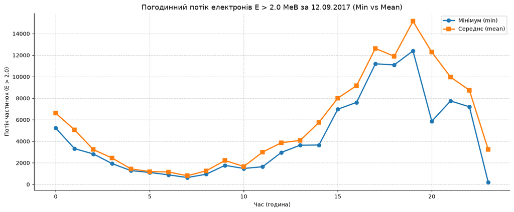

```python
# ВАШ КОД
My_day_mean = A_hourly[
    (A_hourly['ts'].dt.year == 2017) & (A_hourly['ts'].dt.month == 9) & (A_hourly['ts'].dt.day == 12)
].copy()[['E>2.0_mean', 'ts']]

My_day_A =  A[
    (A['ts'].dt.year == 2017) & (A['ts'].dt.month == 9) & (A['ts'].dt.day == 12)
].copy()[['E>2.0', 'ts']]
My_day_min = My_day_A.set_index('ts')['E>2.0'].resample('1h').min()

# 4. Побудова двох кривих на одному графіку
plt.figure(figsize=(12, 5))
plt.plot(
    My_day_min.index.hour,
    My_day_min,
    label='Мінімум (min)',
    marker='o',
    linewidth=2,
    color='tab:blue',
)
plt.plot(
    My_day_mean['ts'].dt.hour,
    My_day_mean['E>2.0_mean'],
    label='Середнє (mean)',
    marker='s',
    linewidth=2,
    color='tab:orange',
)

plt.title(
    'Погодинний потік електронів E > 2.0 МеВ за 12.09.2017 (Min vs Mean)',
    fontsize=12,
)
plt.xlabel('Час (година)')
plt.ylabel('Потік частинок (E > 2.0)')
plt.grid(True, linestyle='--', alpha=0.6)
plt.legend()
plt.tight_layout()
plt.show()
```

**Відповідь 4.2:**

Крива середнього значення завжди вища за криву мінімального значення

Існують моменти, коли криві майже зливаються (~2-10), тобто потік був майже рівномірним, максимальне від мінімального далеко не відходило

Однак є також протилежні хм моменти - великі розриви (20-та година), які показують, що в той момент були висока динаміка та нестабільність

Різниця між даними важлива, коли : потрібно знати загальну оцінку потоку частинок (середнє), або ж коли потрібно знати, за яку межу потік не опускався

### Завдання 4.3

Об'єднайте три таблиці в одну — назвіть її `M`. Виведіть її розмір і всі рядки, у яких є хоча б один пропуск.

**Зверніть увагу:** таблиці закінчуються не в один і той самий момент. Тому результат залежить від того, який тип об'єднання ви оберете (`how='inner'` чи `how='outer'`). Спробуйте обидва, подивіться, чим відрізняється кількість рядків, і поясніть свій вибір.

```python
# ВАШ КОД
hourly_keys = ['Year', 'Month', 'Day', 'Hour', 'ts']
daily_keys = ['Year', 'Month', 'Day', 'ts']

M_outer = pd.merge(A_hourly, C, on=hourly_keys, how='outer')
M_outer = pd.merge(M_outer, B, on=daily_keys, how='outer')

M_inner = pd.merge(A_hourly, C, on=hourly_keys, how='inner')
M_inner = pd.merge(M_inner, B, on=daily_keys, how='inner')

print('Розмір M (outer):',M_outer.shape )
print('Розмір M (inner):', M_inner.shape)

null_rows_out = M_outer[M_outer.isna().any(axis=1)]
null_rows_inn = M_inner[M_inner.isna().any(axis=1)]

print('\nКількість рядків із пропусками в M_outer:', len(null_rows_out))
print('Рядки з пропусками:')
display(null_rows_out)

print('\nКількість рядків із пропусками в M_inner:', len(null_rows_inn))
print('Рядки з пропусками:')
display(null_rows_inn)

M = M_outer.copy()
```

```
Розмір M (outer): (601, 24)
Розмір M (inner): (25, 24)

Кількість рядків із пропусками в M_outer: 576
Рядки з пропусками:
```

|  | ts | P>1_mean | P>1_max | P>5_mean | P>5_max | P>10_mean | P>10_max | P>30_mean | P>30_max | P>50_mean | P>50_max | P>100_mean | P>100_max | E>0.8_mean | E>0.8_max | E>2.0_mean | E>2.0_max | Year | Month | Day | Hour | Speed | Density | Radio Flux 10.7 |
| --- | --- | --- | --- | --- | --- | --- | --- | --- | --- | --- | --- | --- | --- | --- | --- | --- | --- | --- | --- | --- | --- | --- | --- | --- |
| 1 | 2017-08-28 01:00:00 | 7.994167 | 13.600000 | 0.291667 | 0.512 | 0.156583 | 0.259 | 0.072583 | 0.0919 | 0.058700 | 0.0798 | 0.029950 | 0.0471 | 18091.666016 | 20600.0 | 713.000000 | 907.0 | 2017 | 8 | 28 | 1 | 305.0 | 3.4 | NaN |
| 2 | 2017-08-28 02:00:00 | 6.099167 | 10.800000 | 0.283000 | 0.479 | 0.177667 | 0.321 | 0.084450 | 0.1210 | 0.069642 | 0.1110 | 0.035025 | 0.0595 | 14108.333008 | 15000.0 | 380.833344 | 475.0 | 2017 | 8 | 28 | 2 | 309.0 | 1.7 | NaN |
| 3 | 2017-08-28 03:00:00 | 4.752500 | 7.760000 | 0.236833 | 0.329 | 0.166333 | 0.244 | 0.087658 | 0.1800 | 0.068092 | 0.1390 | 0.035517 | 0.0818 | 12766.666992 | 13100.0 | 267.916656 | 284.0 | 2017 | 8 | 28 | 3 | 304.0 | 2.0 | NaN |
| 4 | 2017-08-28 04:00:00 | 4.158333 | 6.620000 | 0.334917 | 0.539 | 0.208333 | 0.309 | 0.084800 | 0.1530 | 0.072850 | 0.1420 | 0.039708 | 0.0694 | 11333.333008 | 12300.0 | 203.000000 | 234.0 | 2017 | 8 | 28 | 4 | 302.0 | 2.3 | NaN |
| 5 | 2017-08-28 05:00:00 | 2.904166 | 4.620000 | 0.240333 | 0.410 | 0.166833 | 0.284 | 0.077292 | 0.1140 | 0.063692 | 0.0932 | 0.034883 | 0.0669 | 9685.833008 | 10700.0 | 152.416672 | 180.0 | 2017 | 8 | 28 | 5 | 304.0 | 2.4 | NaN |
| ... | ... | ... | ... | ... | ... | ... | ... | ... | ... | ... | ... | ... | ... | ... | ... | ... | ... | ... | ... | ... | ... | ... | ... | ... |
| 596 | 2017-09-21 20:00:00 | 42.102501 | 78.900002 | 0.397500 | 0.833 | 0.226833 | 0.429 | 0.089325 | 0.1380 | 0.069983 | 0.1050 | 0.039692 | 0.0737 | 178750.000000 | 186000.0 | 63175.000000 | 70500.0 | 2017 | 9 | 21 | 20 | 379.0 | 1.8 | NaN |
| 597 | 2017-09-21 21:00:00 | 50.783337 | 71.699997 | 0.489250 | 0.788 | 0.317583 | 0.501 | 0.121358 | 0.2040 | 0.077467 | 0.1470 | 0.033417 | 0.0524 | 175833.328125 | 177000.0 | 58350.000000 | 60300.0 | 2017 | 9 | 21 | 21 | 380.0 | 1.8 | NaN |
| 598 | 2017-09-21 22:00:00 | 39.000000 | 48.799999 | 0.350000 | 0.536 | 0.200250 | 0.310 | 0.094358 | 0.1430 | 0.070633 | 0.1080 | 0.039600 | 0.0798 | 167750.000000 | 176000.0 | 49366.667969 | 54400.0 | 2017 | 9 | 21 | 22 | 387.0 | 1.1 | NaN |
| 599 | 2017-09-21 23:00:00 | 28.824999 | 42.099998 | 0.465000 | 0.861 | 0.257833 | 0.506 | 0.113575 | 0.1680 | 0.078108 | 0.1110 | 0.045125 | 0.0733 | 150083.328125 | 160000.0 | 37525.000000 | 44400.0 | 2017 | 9 | 21 | 23 | 380.0 | 1.0 | NaN |
| 600 | 2017-09-22 00:00:00 | NaN | NaN | NaN | NaN | NaN | NaN | NaN | NaN | NaN | NaN | NaN | NaN | NaN | NaN | NaN | NaN | 2017 | 9 | 22 | 0 | 381.0 | 1.0 | NaN |

576 rows × 24 columns

```
Кількість рядків із пропусками в M_inner: 0
Рядки з пропусками:
```

|  | ts | P>1_mean | P>1_max | P>5_mean | P>5_max | P>10_mean | P>10_max | P>30_mean | P>30_max | P>50_mean | P>50_max | P>100_mean | P>100_max | E>0.8_mean | E>0.8_max | E>2.0_mean | E>2.0_max | Year | Month | Day | Hour | Speed | Density | Radio Flux 10.7 |
| --- | --- | --- | --- | --- | --- | --- | --- | --- | --- | --- | --- | --- | --- | --- | --- | --- | --- | --- | --- | --- | --- | --- | --- | --- |

**Відповідь 4.3:** Я обрала залишити таблицю з зовнішнім з'єднанням. Саме у такій таблиці жодні дані не пропали, хоча вона і займає багато місця

### Завдання 4.4 — поділ на групи

Щоб далі було що з чим порівнювати, поділіть години на три групи за значенням **максимуму потоку P>10 за годину**:

| Група | Умова |
| --- | --- |
| `тиха` | менше 10 |
| `активна` | від 10 до 1000 |
| `дуже активна` | 1000 і більше |

Додайте до `M` стовпець `група` і виведіть, скільки годин потрапило в кожну.

> Це не вигадані числа: саме такі пороги використовує метеослужба космічної погоди NOAA. Чому вони саме такі — питання не сьогоднішньої роботи.

```python
# ВАШ КОД
bins = [-np.inf, 10, 1000, np.inf]
labels = ['тиха', 'активна', 'дуже активна']

M['група'] = pd.cut(M['P>10_max'], bins=bins, labels=labels, right=False)

print('Кількість годин у кожній групі:')
print(M['група'].value_counts())
```

```
Кількість годин у кожній групі:
група
тиха            411
активна         171
дуже активна     18
Name: count, dtype: int64
```

**Самоперевірка етапу 4.**

```python
assert M is not None, 'таблиця M не побудована'
assert 'ts' in M.columns, 'у таблиці M потрібен стовпець ts'
assert 'група' in M.columns, 'у таблиці M потрібен стовпець «група»'
assert 590 <= len(M) <= 605, 'очікується близько 600 рядків, а є %d — перевірте об’єднання' % len(M)
print('Етап 4 пройдено:', len(M), 'рядків')
```

```
Етап 4 пройдено: 601 рядків
```

# Етап 5. П'ять графіків — п'ять питань

Графік будується як **відповідь на питання**, а не «щоб був».

**Вимоги до кожного графіка:**

- підписані обидві осі, з одиницями вимірювання;
- заголовок;
- під графіком, у текстовій клітинці, — **одне речення про дані**. Не «на графіку зображено потік протонів», а твердження на кшталт «більшість годин потік не перевищує 60, але кілька годин дають значення у сотні разів більші».

> Не кожне питання має відповідь «так, зв'язок є». Якщо на графіку нічого не видно — так і напишіть. Відсутність зв'язку — це теж результат, і чесно про неї написати важливіше, ніж підбирати ракурс, у якому «щось наче проглядається».

### Графік 1. Як розподілені значення вашого потоку?

Побудуйте гістограму вашого потоку (середнє за годину). Порахуйте окремо середнє й медіану цього стовпця.

Якщо гістограма вийде нечитабельною — стовпчик біля нуля і порожньо далі — не залишайте так. Спробуйте побудувати гістограму від логарифма значень (`np.log10`) і подивіться, що зміниться.

**Питання:** чому середнє й медіана так сильно відрізняються?

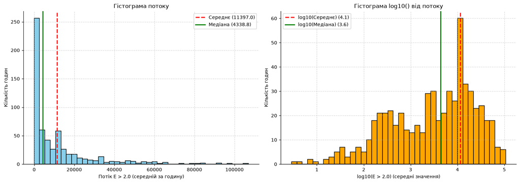

```python
# ВАШ КОД
data = M['E>2.0_mean'].dropna()

mean_val = data.mean()
median_val = data.median()

fig, axes = plt.subplots(1, 2, figsize=(14, 5))

axes[0].hist(data, bins=40, color='skyblue', edgecolor='black')
axes[0].axvline(
    mean_val,
    color='red',
    linestyle='--',
    linewidth=2,
    label=f'Середнє ({mean_val:.1f})',
)
axes[0].axvline(
    median_val,
    color='green',
    linestyle='-',
    linewidth=2,
    label=f'Медіана ({median_val:.1f})',
)
axes[0].set_title('Гістограма потоку')
axes[0].set_xlabel('Потік E > 2.0 (середній за годину)')
axes[0].set_ylabel('Кількість годин')
axes[0].legend()
axes[0].grid(True, linestyle='--', alpha=0.5)

log_data = np.log10(data[data > 0])

axes[1].hist(log_data, bins=40, color='orange', edgecolor='black')
axes[1].axvline(
    np.log10(mean_val),
    color='red',
    linestyle='--',
    linewidth=2,
    label=f'log10(Середнє) ({np.log10(mean_val):.1f})',
)
axes[1].axvline(
    np.log10(median_val),
    color='green',
    linestyle='-',
    linewidth=2,
    label=f'log10(Медіана) ({np.log10(median_val):.1f})',
)
axes[1].set_title('Гістограма log10() від потоку')
axes[1].set_xlabel('log10(E > 2.0) (середні значення)')
axes[1].set_ylabel('Кількість годин')
axes[1].legend()
axes[1].grid(True, linestyle='--', alpha=0.5)

plt.tight_layout()
plt.show()
```

**Висновок:** Середнє та медіана відрізняються через наявність рідкісних, однак екстримально великих значень. Середнє дуже чутливе до таких сплесків, тому зміщене правіше від медіани

### Графік 2. Чи відрізняється швидкість вітру між групами годин?

Побудуйте діаграму розмаху (`boxplot`) швидкості сонячного вітру окремо для кожної групи з завдання 4.4.

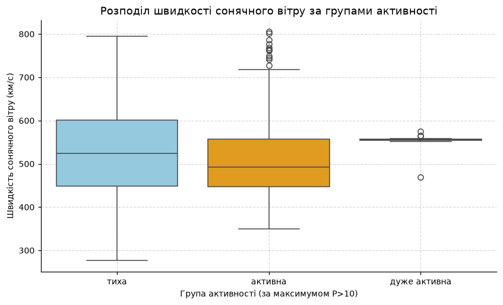

```python
# ВАШ КОД
plt.figure(figsize=(9, 5))
sns.boxplot(
    data=M,
    x='група',
    y='Speed',
    order=['тиха', 'активна', 'дуже активна'],
    palette=['skyblue', 'orange', 'crimson'],
)

plt.title(
    'Розподіл швидкості сонячного вітру за групами активності', fontsize=12
)
plt.xlabel('Група активності (за максимумом P>10)')
plt.ylabel('Швидкість сонячного вітру (км/с)')
plt.grid(True, linestyle='--', alpha=0.5)
plt.show()
```

**Висновок:** Зі збільшенням активності сонячних протонів медіанна швидкість сонячного вітру помітно від тихої групи до дуже активної. Хоч медіана на активній групі зменшилась, з'явилися викиди поза 800 км/с

### Графік 3. Чи пов'язані змінні вашої пари?

Побудуйте діаграму розсіювання для пари з вашого завдання. Порахуйте коефіцієнт кореляції між ними.

```
Коефіцієнт кореляції Пірсона: -0.039
Коефіцієнт кореляції Спірмена: 0.016
```

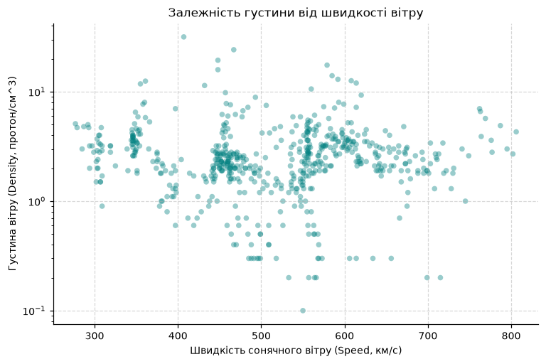

```python
# ВАШ КОД
corr_pearson = M['Speed'].corr(M['Density'])
corr_spearman = M['Speed'].corr(M['Density'], method='spearman')

print(f'Коефіцієнт кореляції Пірсона: {corr_pearson:.3f}')
print(f'Коефіцієнт кореляції Спірмена: {corr_spearman:.3f}')

plt.figure(figsize=(8, 5))
plt.scatter(
    M['Speed'],
    M['Density'],
    alpha=0.4,
    color='teal',
    edgecolors='none',
    s=25,
)

plt.yscale('log')

plt.title(
    f'Залежність густини від швидкості вітру'
)
plt.xlabel('Швидкість сонячного вітру (Speed, км/с)')
plt.ylabel('Густина вітру (Density, протон/см^3)')
plt.grid(True, linestyle='--', alpha=0.5)
plt.show()
```

**Висновок:** Обидва коефіцієнти кореляції фактично дорівнюють нулю, тобто немає будь-якої лінійної або монотонної залежності між швидкістю сонячного вітру та його густиною

### Графік 4. Скільки годин у кожній групі?

Побудуйте стовпчикову діаграму кількості годин за групами. Підпишіть кожен стовпчик кількістю годин і відсотком від загальної кількості.

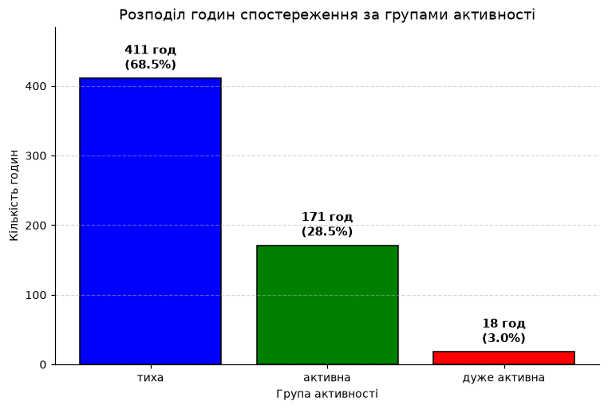

```python
# ВАШ КОД
counts = M['група'].value_counts().reindex(['тиха', 'активна', 'дуже активна'])
total = len(M['група'].dropna())
percentages = (counts / total) * 100

plt.figure(figsize=(8, 5))
bars = plt.bar(
    counts.index,
    counts.values,
    color=['blue', 'green', 'red'],
    edgecolor='black',
)

for bar, count, pct in zip(bars, counts.values, percentages.values):
    height = bar.get_height()
    plt.text(
        bar.get_x() + bar.get_width() / 2.0,
        height + (max(counts.values) * 0.02),
        f'{count} год\n({pct:.1f}%)',
        ha='center',
        va='bottom',
        fontsize=10,
        fontweight='bold',
    )

plt.title('Розподіл годин спостереження за групами активності', fontsize=12)
plt.xlabel('Група активності')
plt.ylabel('Кількість годин')
plt.ylim(0, max(counts.values) * 1.18)
plt.grid(axis='y', linestyle='--', alpha=0.5)
plt.show()
```

**Висновок:** Більшість часу протони не сильно активні (трои більше як 2/3 часу), щоактивніша група, то менше часу вона відбувалась

### Графік 5. Як усе це виглядало в часі?

Побудуйте лінійний графік максимуму потоку P>10 за годину за весь період спостережень.

Якщо крива виявиться нечитабельною — згадайте, що допомогло в графіку 1.

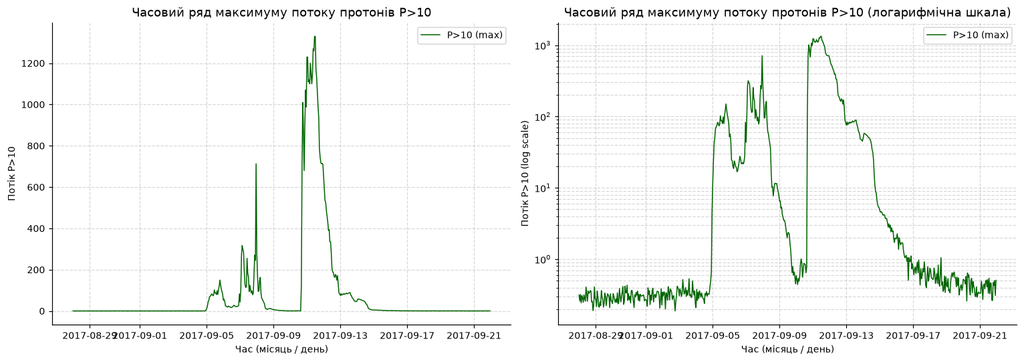

```python
# ВАШ КОД
M_sorted = M.sort_values('ts')

fig, axes = plt.subplots(1, 2, figsize=(14, 5))
axes[0].plot(
    M_sorted['ts'],
    M_sorted['P>10_max'],
    color='darkgreen',
    linewidth=1,
    label='P>10 (max)',
)
axes[0].set_title(
    'Часовий ряд максимуму потоку протонів P>10',
    fontsize=12,
)
axes[0].set_xlabel('Час (місяць / день)')
axes[0].set_ylabel('Потік P>10')
axes[0].grid(True, which='both', linestyle='--', alpha=0.5)
axes[0].legend(loc='upper right')

axes[1].plot(
    M_sorted['ts'],
    M_sorted['P>10_max'],
    color='darkgreen',
    linewidth=1,
    label='P>10 (max)',
)
axes[1].set_yscale('log')
axes[1].set_title(
    'Часовий ряд максимуму потоку протонів P>10 (логарифмічна шкала)',
    fontsize=12,
)
axes[1].set_xlabel('Час (місяць / день)')
axes[1].set_ylabel('Потік P>10 (log scale)')
axes[1].grid(True, which='both', linestyle='--', alpha=0.5)
axes[1].legend(loc='upper right')

plt.tight_layout()
plt.show()
```

# Етап 6. Два графіки одних і тих самих даних

Нижче побудовано два графіки. Дані в них **одні й ті самі** — це той самий стовпець з тієї самої таблиці, жодне число не змінено.

Виконайте клітинку й подивіться на обидва.

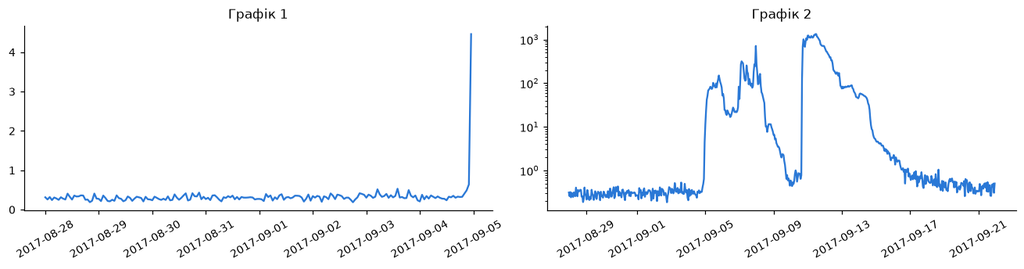

```python
СТОВПЕЦЬ = 'P>10_max'   # <- впишіть назву свого стовпця з МАКСИМУМОМ P>10 за годину

вікно = M[(M['ts'] >= '2017-08-28') & (M['ts'] < '2017-09-05')]

fig, ax = plt.subplots(1, 2, figsize=(12, 3.2))

ax[0].plot(вікно['ts'], вікно[СТОВПЕЦЬ], color='#2a78d6')
ax[0].set_title('Графік 1')
ax[0].tick_params(axis='x', rotation=30)

ax[1].plot(M['ts'], M[СТОВПЕЦЬ], color='#2a78d6')
ax[1].set_yscale('log')
ax[1].set_title('Графік 2')
ax[1].tick_params(axis='x', rotation=30)

fig.tight_layout()
plt.show()
```

### Завдання 6.1

Дайте відповідь на три питання:

1. Який висновок про космічну погоду у вересні 2017 року зробить людина, яка бачила **тільки перший** графік?
2. Який висновок зробить людина, яка бачила **тільки другий**?
3. Чим ці два графіки відрізняються між собою? Назвіть **дві** відмінності — вони обидві є в коді вище.

*Жодне число в обох графіках не підроблене. Різниця виникла тільки через те, як їх побудували.*

### Завдання 6.2

Уявіть, що вам потрібно **одним графіком** чесно показати, що відбувалося в цьому періоді. Побудуйте його самі й підпишіть заголовком, який формулює висновок.

Поясніть у клітинці нижче, чому ви обрали саме такий вигляд.

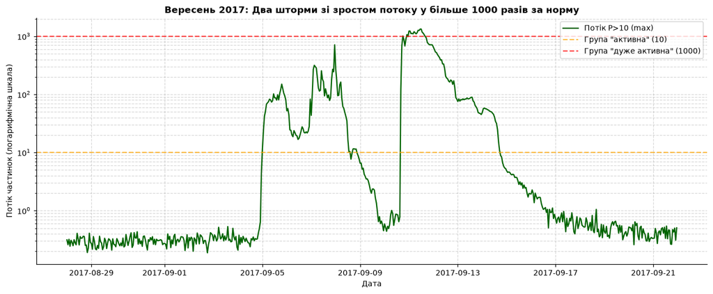

```python
# ВАШ КОД
M_sorted = M.sort_values('ts')

plt.figure(figsize=(12, 5))
plt.plot(
    M_sorted['ts'],
    M_sorted['P>10_max'],
    color='darkgreen',
    linewidth=1.5,
    label='Потік P>10 (max)',
)

plt.yscale('log')

plt.axhline(
    10,
    color='orange',
    linestyle='--',
    alpha=0.7,
    label='Група "активна" (10)'
)
plt.axhline(
    1000,
    color='red',
    linestyle='--',
    alpha=0.7,
    label='Група "дуже активна" (1000)',
)

plt.title(
    'Вересень 2017: Два шторми зі зростом потоку у більше 1000 разів за норму',
    fontsize=11,
    fontweight='bold',
)
plt.xlabel('Дата')
plt.ylabel('Потік частинок (логарифмічна шкала)')
plt.grid(True, which='both', linestyle='--', alpha=0.5)
plt.legend(loc='upper right')
plt.tight_layout()
plt.show()
```

.**Відповідь 6.2:** Даний графік показує увест часовий період та використовує логарифмування для того, щоб не губити ані дрібних деталей, ані екстремумів

# Етап 7. Три спостереження та ваше питання

### Завдання 7.1

Запишіть **три спостереження** про ці дані, які ви зробили під час роботи.

Спостереження — це твердження, яке спирається на конкретне число або графік з вашого ноутбука. Не «дані цікаві», а, наприклад, «максимальне значення потоку у 2000 разів більше за медіанне, і всі такі години припадають на одні й ті самі три доби».

Для кожного вкажіть, **де саме** у вашій роботі його видно.

**Спостереження 1:** У стовпці E>2.0_mean середнє значення (11397) перевищує медіану (4338.8) майже в 2.6 рази. Це доводить, що більшість часу потік перебуває в спокійному стані з низькими значеннями, а середнє значення сильно витягнуте вгору невеликою кількістю екстремальних спалахів

**Спостереження 2:** Більш ніж 2/3 всього часу спостережень (~70%) припадає на групу «тиха» (P>10_max < 10), тоді як події групи «дуже активна» трапляються рідше ніж у 5% годин. Виплески протонів є рідкісними імпульсними подіями, а не стаціонарним шумом

### Завдання 7.2 — ваше індивідуальне питання

Дайте відповідь на додаткове питання зі свого завдання. Відповідь має спиратися на обчислення: наведіть код і результат, а потім сформулюйте висновок словами.

```python
# ВАШ КОД
time_cols = [
    'Year',
    'Month',
    'Day',
    'Hour',
    'Minute',
    'Julian date',
    'Seconds in day',
]
numeric_df = M.select_dtypes(include=['number']).drop(
    columns=time_cols, errors='ignore'
)

cv_results = (numeric_df.std() / numeric_df.mean()).abs()

cv_sorted = cv_results.sort_values(ascending=False)

print('Коефіцієнт варіації (медіана / середнє) для всіх стовпців:')
print(cv_sorted)

print(
    f'\nНайбільший розкид має стовпець: "{cv_sorted.index[0]}" (CV = {cv_sorted.iloc[0]:.2f})'
)
```

```
Коефіцієнт варіації (медіана / середнє) для всіх стовпців:
P>100_mean         4.308374
P>100_max          4.223354
P>50_mean          3.842017
P>50_max           3.778265
P>30_mean          3.569527
P>30_max           3.510205
P>10_mean          2.901722
P>10_max           2.826926
P>1_max            2.654705
P>5_mean           2.476875
P>5_max            2.441740
P>1_mean           2.167933
E>2.0_mean         1.474061
E>2.0_max          1.423943
Density            0.883661
E>0.8_mean         0.799040
E>0.8_max          0.759051
Radio Flux 10.7    0.239608
Speed              0.216257
dtype: float64

Найбільший розкид має стовпець: "P>100_mean" (CV = 4.31)
```

**Відповідь 7.2:** Найбільший розкид має стовпець P>100_mean, як один з високоенергетичних потоків, де дві мінімальні зміни мінімального та максимального можуть дати велику зміну середнього

# Етап 8. Декларація про використання інструментів штучного інтелекту

Користуватися мовними моделями під час виконання цієї роботи **дозволено**. Це нормальна інженерна практика, і курс про штучний інтелект не має підстав її забороняти.

Обов'язковою є прозорість: ви вказуєте, де саме і як скористалися інструментом — так само, як у науковій статті вказують використане програмне забезпечення. **Задекларована допомога порушенням не є.**

Порушенням є інше: здати роботу, яку ви не можете пояснити. На захисті вас попросять показати конкретний рядок вашого коду, пояснити, чому він саме такий, і внести в нього невелику зміну на місці. Якщо код згенеровано, але ви його розумієте — робота зарахована. Якщо не розумієте — не зарахована, незалежно від того, хто його написав.

### Завдання 8.1

Заповніть словник. Для кожного етапу оберіть одне з формулювань:

- `'ні'` — інструментами ШІ не користувався;
- `'синтаксис'` — питав про назву функції або синтаксис, код писав сам;
- `'код, перевірено'` — код згенеровано, я його прочитав, перевірив і розумію;
- `'текст, перероблено'` — згенеровано чернетку тексту, яку я переписав по суті;
- `'текст, як є'` — згенерований текст залишено майже без змін.

Останній варіант не заборонений, але прямо впливає на оцінку: бали ставляться за висновки, а не за наявність абзацу.

```python
ІНСТРУМЕНТИ_ШІ = 'Gemini'     # напр. 'ChatGPT' або 'не використовував'

ДЕКЛАРАЦІЯ = {
    'етапи 1–2, читання файлу та розбір таблиць': 'ні',
    'етап 3, паспорт даних і дивні значення':     'ні',
    'етап 4, об’єднання таблиць':                 'синтаксис',
    'етап 5, побудова графіків':                  'код, перевірено',
    'етап 5, формулювання висновків':             'текст, перероблено',
    'етапи 6–7, порівняння графіків і спостереження': 'текст, перероблено',
}

# Що саме ви перевірили за згенерованим кодом чи текстом — конкретно:
# які числа звірили, що переписали, де знайшли помилку.
ЩО_ПЕРЕВІРЕНО = 'при створені таблиці A_hourly не було додано усі попередні стовпці, які були важливі у наступних етапах\n' \
'У завданні 4.2 було використано два методи, де мінімальне вибиралося з таблиці А, а середнє з таблиці А_hourly\n' \
'У графіках завдання 5 було змінено кольори, назви та деякі деталі'

ПІДТВЕРДЖУЮ = True
```

```python
# --- перевірка повноти декларації: клітинку не редагувати --------------------
ДОЗВОЛЕНІ = {'ні', 'синтаксис', 'код, перевірено', 'текст, перероблено', 'текст, як є'}

assert ІНСТРУМЕНТИ_ШІ.strip(), 'Вкажіть інструменти або напишіть «не використовував»'
порожні = [k for k, v in ДЕКЛАРАЦІЯ.items() if not str(v).strip()]
assert not порожні, 'Не заповнено пункти декларації: %s' % '; '.join(порожні)
чужі = {v for v in ДЕКЛАРАЦІЯ.values() if v not in ДОЗВОЛЕНІ}
assert not чужі, 'Недопустимі значення: %s. Оберіть з переліку вище.' % ', '.join(sorted(чужі))
assert len(ЩО_ПЕРЕВІРЕНО.strip()) >= 120, ('Опишіть конкретніше, що саме ви перевірили '
                                           '(зараз %d символів, потрібно щонайменше 120)'
                                           % len(ЩО_ПЕРЕВІРЕНО.strip()))
assert ПІДТВЕРДЖУЮ is True, 'Підтвердьте, що можете пояснити власний код на захисті'

print('ДЕКЛАРАЦІЯ ПРО ВИКОРИСТАННЯ ІНСТРУМЕНТІВ ШІ')
print('=' * 78)
print('%-46s %s' % ('автор:', ПІБ))
print('%-46s %s' % ('інструменти:', ІНСТРУМЕНТИ_ШІ))
print('-' * 78)
for k, v in ДЕКЛАРАЦІЯ.items():
    print('%-46s %s' % (k + ':', v))
print('-' * 78)
print('перевірено автором:')
print(ЩО_ПЕРЕВІРЕНО)
print('=' * 78)
print('Автор підтверджує, що може пояснити кожен рядок коду під час захисту.')
```

```
ДЕКЛАРАЦІЯ ПРО ВИКОРИСТАННЯ ІНСТРУМЕНТІВ ШІ
==============================================================================
автор:                                         Бугай Софія
інструменти:                                   Gemini
------------------------------------------------------------------------------
етапи 1–2, читання файлу та розбір таблиць:    ні
етап 3, паспорт даних і дивні значення:        ні
етап 4, об’єднання таблиць:                    синтаксис
етап 5, побудова графіків:                     код, перевірено
етап 5, формулювання висновків:                текст, перероблено
етапи 6–7, порівняння графіків і спостереження: текст, перероблено
------------------------------------------------------------------------------
перевірено автором:
при створені таблиці A_hourly не було додано усі попередні стовпці, які були важливі у наступних етапах
У завданні 4.2 було використано два методи, де мінімальне вибиралося з таблиці А, а середнє з таблиці А_hourly
У графіках завдання 5 було змінено кольори, назви та деякі деталі
==============================================================================
Автор підтверджує, що може пояснити кожен рядок коду під час захисту.
```

# Крок 9. Збереження результату та фінальна самоперевірка

Об'єднана таблиця знадобиться вам у лабораторних роботах № 3 і № 4 — збережіть її й не втрачайте до кінця семестру.

```python
M.to_csv('master_hourly.csv', index=False)
print('збережено:', M.shape)
```

```
збережено: (601, 25)
```

```python
# --- фінальна самоперевірка --------------------------------------------------
перевірки = {
    'ПІБ і варіант заповнено':        bool(ПІБ) and bool(ВАРІАНТ),
    'таблиця A (7200 рядків)':        len(A) == 7200,
    'таблиця B (25 рядків)':          len(B) == 25,
    'таблиця C (601 рядок)':          len(C) == 601,
    'таблиці об’єднано':              M is not None and 590 <= len(M) <= 605,
    'стовпець «група» є':             'група' in M.columns,
    'усі дати у 2017 році':           int(pd.to_datetime(M['ts']).dt.year.min()) == 2017,
    'декларацію заповнено':           bool(ІНСТРУМЕНТИ_ШІ.strip()) and ПІДТВЕРДЖУЮ is True,
}
for k, v in перевірки.items():
    print(('OK   ' if v else 'НЕ ОК') + '  ' + k)

if all(перевірки.values()):
    print('\nТехнічна частина роботи виконана.')
    print('Тепер переконайтеся, що заповнені ВСІ клітинки з відповідями та висновками,')
    print('і виконайте Kernel → Restart & Run All перед здачею.')
```

```
OK     ПІБ і варіант заповнено
OK     таблиця A (7200 рядків)
OK     таблиця B (25 рядків)
OK     таблиця C (601 рядок)
OK     таблиці об’єднано
OK     стовпець «група» є
OK     усі дати у 2017 році
OK     декларацію заповнено

Технічна частина роботи виконана.
Тепер переконайтеся, що заповнені ВСІ клітинки з відповідями та висновками,
і виконайте Kernel → Restart & Run All перед здачею.
```